# 2019 140.651 - Lab 11

### HW5 Problem 1

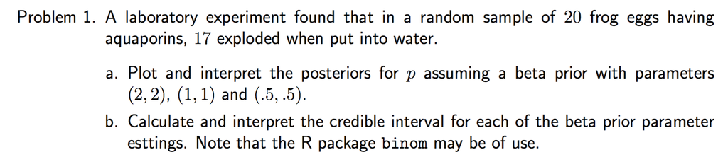

#### a. Plot and interpret the posteriors for p assuming a beta prior with parameters (2, 2), (1, 1) and (.5, .5).

- Assume that data is (one) observation from random variable $X \sim Binom(n, p)$, where $p$ – probability of success (here: egg exploding). Observed data: $n=20$, $x=17$.
- **Prior**. Prior distribution is a distribution that is supposed to reflect what we know about $p$ prior to seeing the data. We assume the prior distribution is $p \sim Beta(\alpha, \beta)$ and is given by probability density function
  $$f(p) = f(p|\alpha, \beta) = \frac{\Gamma(\alpha + \beta)}{\Gamma(\alpha) \Gamma(\beta)} p^{\alpha - 1} (1-p)^{\beta -1}.$$
  In that sense, we consider $p$ to be continuous random variable.
- **Likelihood**. Here, likelihood for $p$ (function of the parameter given the data) is given by probability mass function
  $$L(p):=\operatorname{Pr}(x \mid p) = \binom{n}{x}p^x (1-p)^{n-x}$$
- **Posterior distribution**. It can be derived from Bayes Theorem that combining the prior distribution and the likelihood gives us
  $$f(p \mid x) \propto \operatorname{Pr}(x \mid p) f(p)$$
  where $\propto$ means “proportional to”. Here, the $f(q \mid x)$ will be probability density function because we consider $p$ to be continuous random variable.
  $$\begin{align*}
  f(p \mid x) &= f(p|\alpha, \beta; x) = \text{Prior} \times \text{Likelihood} \\
  &= f(p|\alpha, \beta) \cdot f(x|p)\\
  &= \frac{\Gamma(\alpha + \beta)}{\Gamma(\alpha) \Gamma(\beta)} p^{\alpha - 1} (1-p)^{\beta -1} \cdot \binom{n}{x}p^x (1-p)^{n-x} \\
  & \propto p^{\alpha + x - 1} (1-p)^{(n-x) + \beta - 1} \\
  & = p^{\alpha^{*} - 1} (1-p)^{\beta^{*} - 1}
  \end{align*}$$
  where $\alpha^{*} = \alpha + x$, $\beta^{*} = (n-x) + \beta$.
- To tell what distribution $f(q \mid x)$ represents, we “look” at the $f(q \mid x)$ formula we got and “recognize” it being PDF of some distribution we know. Here, we see the last line is close to density of $Beta(\alpha^{*}, \beta^{*})$ distribution up to a scalar (here, scalar := expression free from parameter $p$):
  $$\frac{\Gamma(\alpha^{*} + \beta^{*})}{\Gamma(\alpha^{*}) \Gamma(\beta^{*})} p^{\alpha^{*} - 1} (1-p)^{\beta^{*} -1} = \text{scalar} \cdot p^{\alpha^{*} - 1} (1-p)^{\beta^{*} -1}$$
  hence we conclude the posterior distribution of $p$ is $Beta(\alpha^{*}, \beta^{*})$ = $Beta(\alpha + x, (n-x) + \beta)$.
- Note the posterior distribution combines infromation from both:
  - prior distribution, as it uses so-called hyperparameters $\alpha$, $\beta$,
  - data (likelihood), as it uses $x$ and $n$.

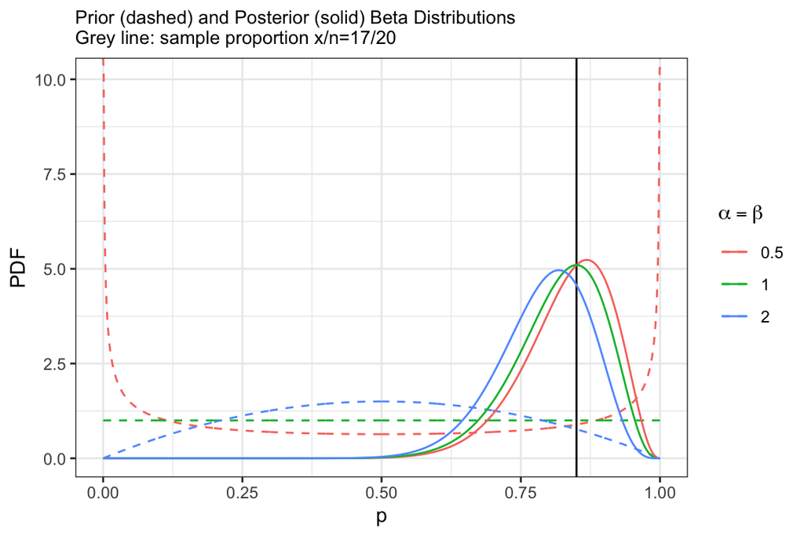

```r
n <- 20
x <- 17
p <- seq(0, 1, length = 1000)

# Calculate priors and posterior
beta.params <- list(c(2, 2), c(1, 1), c(0.5, 0.5))
priors <- lapply(beta.params, function(param, p)
  dbeta(p, param[1], param[2]), p = p)
posteriors <- lapply(beta.params, function(param, p)
  dbeta(p, param[1]+ x, n - x + param[2]), p = p)

# Translate into df and plot
data.frame(p = rep(p, 3), param = rep(c(2, 1, 0.5), each = 1000),
           prior = unlist(priors), posterior = unlist(posteriors)) %>%
  ggplot(aes(x = p, color = factor(param))) +
  geom_vline(xintercept = 17/20) +
  geom_line(aes(y = prior), linetype = 2) +
  geom_line(aes(y = posterior)) +
  labs(title = "Prior (dashed) and Posterior (solid) Beta Distributions\nGrey line: sample proportion x/n=17/20",
       x = "p", y = "PDF", color = TeX('$\\alpha = \\beta$')) +
  theme_bw() + theme(plot.title = element_text(size=10))
```

- Note that when $\alpha = \beta = 1$, the distribution follows a uniform distribution.
- The posterior pools information from both the prior and the likelihood to derive a probability distribution for the value of $p$.

#### b. Calculate and interpret the credible interval for each of the beta prior parameter settings. Note that the R package `binom` may be of use.

##### Conducting Bayesian inference for $p$: credible intervals

$1-\alpha$ credible interval for $p$ is $[a,b]$ such that numbers $a$ and $b$ satisfy:
$$P(a \leq p \leq b | x)=1-\alpha.$$
where we use derived posterior distribution for $p$ (here: $Beta(\alpha^{*}, \beta^{*})$ = $Beta(\alpha + x, (n-x) + \beta)$) to derive the value of. Note once we know posterior distribution for $p$, the values $a,b$ are fixed.

##### Conducting Bayesian inference for $p$: interpretation of credible intervals

Note with Bayesian inference:

- $p$, the true success probability, is a random variable (whereas for frequentist confidence intervals, $p$ is a fixed unknown parameter).
- Bounds of the credible intervals, $a$ and $b$, are fixed numbers (whereas for frequentist confidence intervals, bounds of the confidence intervals are random variables).

Interpretation:

- (Example for prior $Beta(0.5,0.5)$): **The probability that $p$ is between 0.68 and 0.97 is 95%**.

Two methods for picking $a$ and $b$:

1. the equal-tailed,
2. the highest posterior density (HPD) interval.

See [a nice plot comparing the two here](https://stats.stackexchange.com/questions/240749/how-to-find-95-credible-interval). Further reference: textbook, 14.3 Bayesian intervals (p. 430).

##### Solution to problem: using `binom.bayes` to compute credible intervals

```r
?binom.bayes
```

```
binom.bayes(x, n,
            conf.level = 0.95,
            type = c("highest", "central"),
            prior.shape1 = 0.5,
            prior.shape2 = 0.5,
            tol = .Machine$double.eps^0.5,
            maxit = 1000, ...)

The default type of interval constructed is "highest" which computes the highest probability density (hpd) interval which assures the shortest interval possible. The hpd intervals will achieve a probability that is within tol of the specified conf.level. Setting type to "central" constructs interval…
```

For each of the credible intervals below, the probability that $p$ is within the interval is 95%.

```r
library(binom)

# 95% credible interval for a Beta(2,2) prior
binom.bayes(x, n, prior.shape1 = 2, prior.shape2 = 2)
```

```
##   method  x  n shape1 shape2      mean     lower     upper  sig
## 1  bayes 17 20     19      5 0.7916667 0.6314496 0.9378542 0.05
```

```r
## as above, but pulling the credible intervals only
binom.bayes(x, n, prior.shape1 = 2, prior.shape2 = 2)[c("lower", "upper")]
```

```
##       lower     upper
## 1 0.6314496 0.9378542
```

```r
# 95% credible interval for a Beta(1,1) prior
binom.bayes(x, n, prior.shape1 = 1, prior.shape2 = 1)[c("lower", "upper")]
```

```
##       lower     upper
## 1 0.6599475 0.9591231
```

```r
# 95% credible interval for a Beta(0.5,0.5) prior
binom.bayes(x, n, prior.shape1 = 0.5, prior.shape2 = 0.5)[c("lower", "upper")]
```

```
##       lower     upper
## 1 0.6773164 0.9698094
```

### HW5 Problem 3

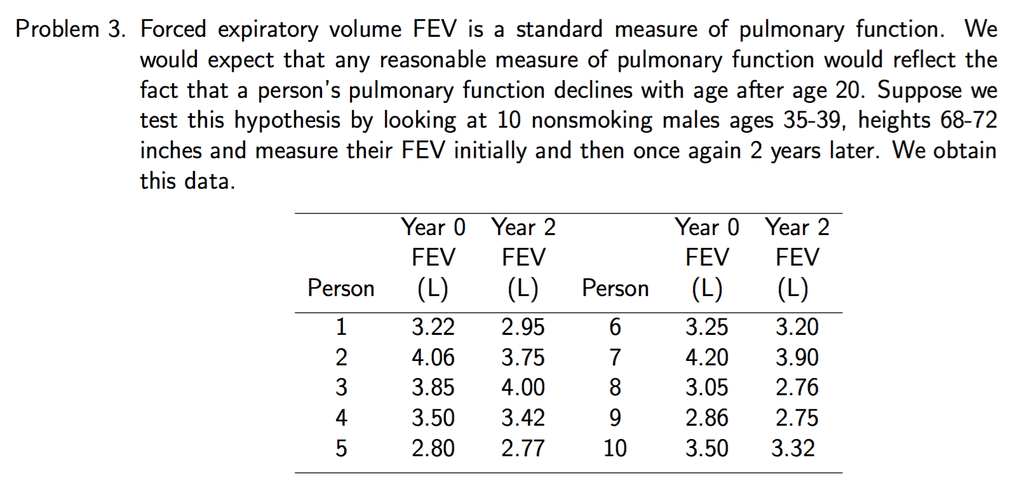

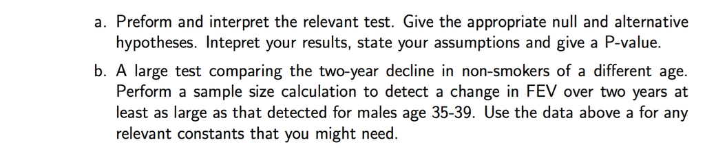

#### a. Preform and interpret the relevant test. Give the appropriate null and alternative hypotheses. Intepret your results, state your assumptions and give a P-value.}

Let $D_i$ denote the difference in FEV between Year 2 and Year 0 for individual $i$, and assume that $D_i \stackrel{iid}{\sim} N(\mu_D, \sigma^2)$. Then, we want to test,

$$\begin{align*}
H_0 &: \mu_D = 0 \\
H_A &: \mu_D \neq 0
\end{align*}$$

Since $n$ is small, we can use the t-test to test our hypothesis.

```r
fev0 <- c(3.22, 4.06, 3.85, 3.50, 2.80,
          3.25, 4.20, 3.05, 2.86, 3.50)
fev2 <- c(2.95, 3.75, 4.00, 3.42, 2.77,
          3.20, 3.90, 2.76, 2.75, 3.32)
diff <- fev2 - fev0
t.test(diff)
```

```
##
##  One Sample t-test
##
## data:  diff
## t = -3.0891, df = 9, p-value = 0.01295
## alternative hypothesis: true mean is not equal to 0
## 95 percent confidence interval:
##  -0.25465006 -0.03934994
## sample estimates:
## mean of x
##    -0.147
```

For $\alpha = 0.05$, we reject the null and conclude that there may be a change in FEV between Year 2 and Year 0 for individuals in this population. The 95% confidence interval is given by $(-0.25, -0.04)$ which does not contain 0, further verifying that the difference in FEV between the two years is not zero.

#### b. A large test comparing the two-year decline in non-smokers of a different age. Perform a sample size calculation to detect a change in FEV over two years at least as large as that detected for males age 35-39. Use the data above a for any relevant constants that you might need.

- Suppose we want a two-sided test for the change in FEV.
- And 80% power and $\alpha = 0.05$ (**must specify desired power and $\alpha$ level**).
- Estimate the mean and standard deviation of the 2-year FEV difference from the current study and use `power.t.test` for sample size claculation.

```r
power.t.test(delta = mean(diff), sd = sd(diff),
             power = 0.8, sig.level = 0.05,
             alternative = "two.sided", type = "one.sample")
```

```
##
##      One-sample t test power calculation
##
##               n = 10.30858
##           delta = 0.147
##              sd = 0.1504844
##       sig.level = 0.05
##           power = 0.8
##     alternative = two.sided
```

Since $n$ is integer valued, we find we need a sample size of 11 individuals to achieve the desired power for an $\alpha = 0.05$ test.

### Book Chapter 18 Problem 10 (p. 554)

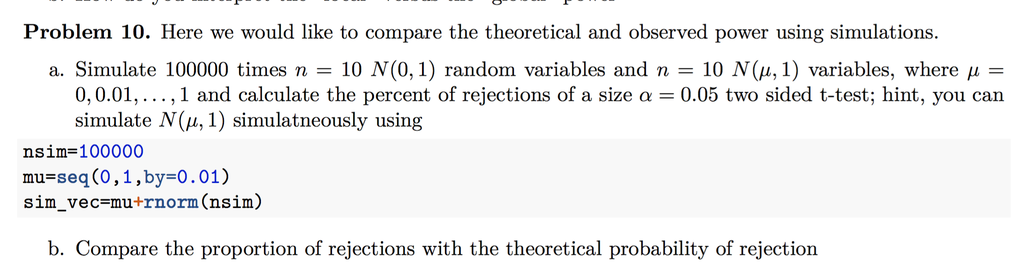

#### a. Empirical power

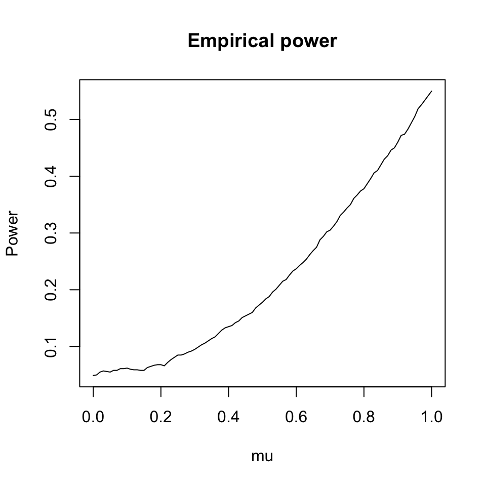

```r
set.seed(34534)
nsim = 1000
samp_null = matrix(rnorm(10*nsim), nrow=nsim)
error_alt = matrix(rnorm(10*nsim), nrow=nsim)

mu = seq(0,1,by=0.01)
pwr = vector(length=length(mu))
for (i in 1:length(mu)){
    pwr[i] = mean(sapply(1:nsim, function(x) t.test(samp_null[x,], mu[i]+error_alt[x,], var.equal=TRUE)$p.value<0.05))
}
plot(mu, pwr, xlab="mu", ylab="Power", main="Empirical power", type="l")
```

#### b. Theoretical power

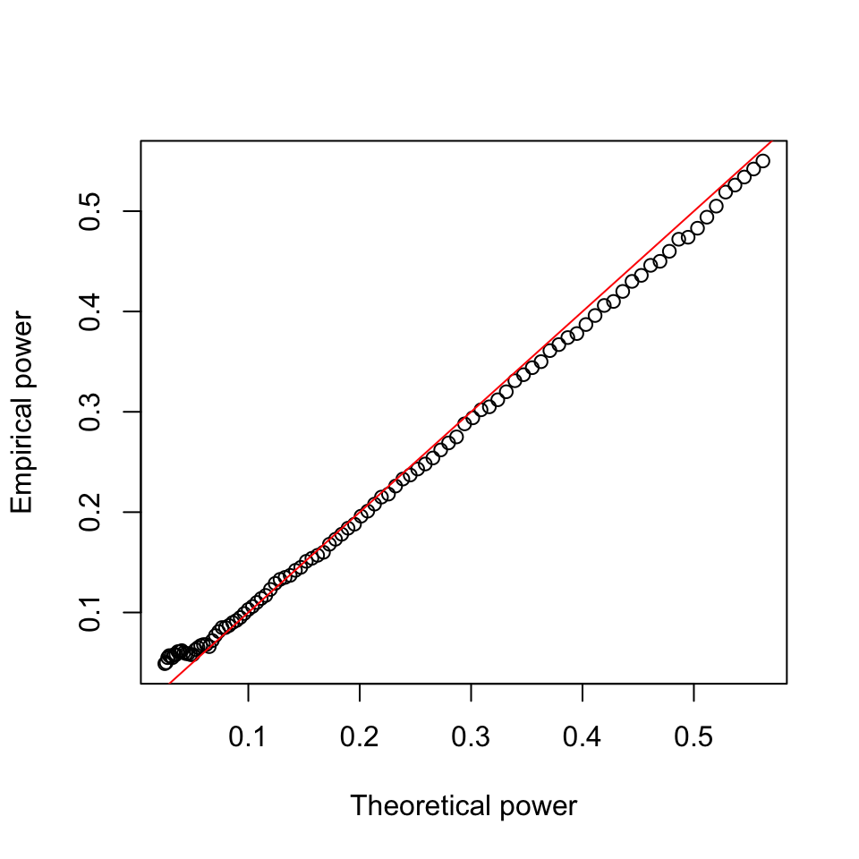

```r
pwr.theo = power.t.test(10,delta=mu, type="two.sample")$power
plot(pwr.theo, pwr, xlab="Theoretical power", ylab = "Empirical power", main="")
abline(a=0, b=1, col="red")
```